# Daily Turbidity Summaries

California Department of Water Resources

31 October, 2026, 04:30

## Daily average turbidities

This is a summary of daily average turbidity for several stations in the Delta.

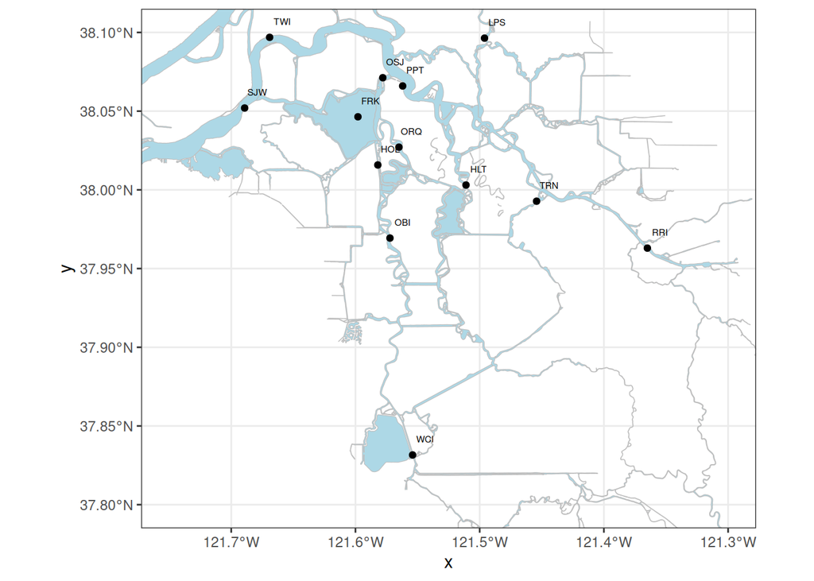

## Here is the average turbidity for the past 7 days

(all stations combined, first turbidity, then secchi)

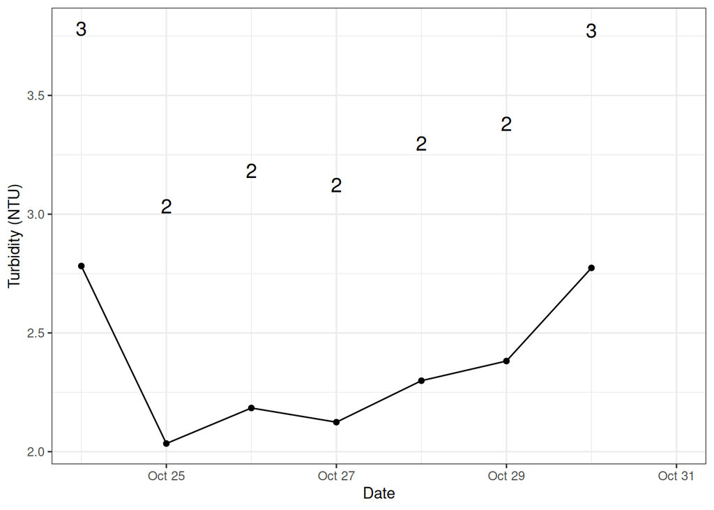

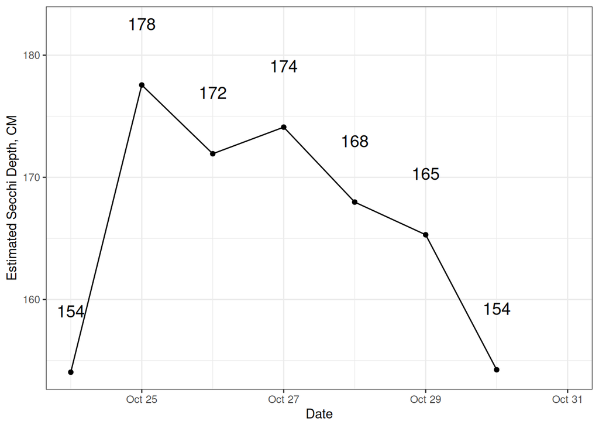

Here are the daily averages from the individual stations.

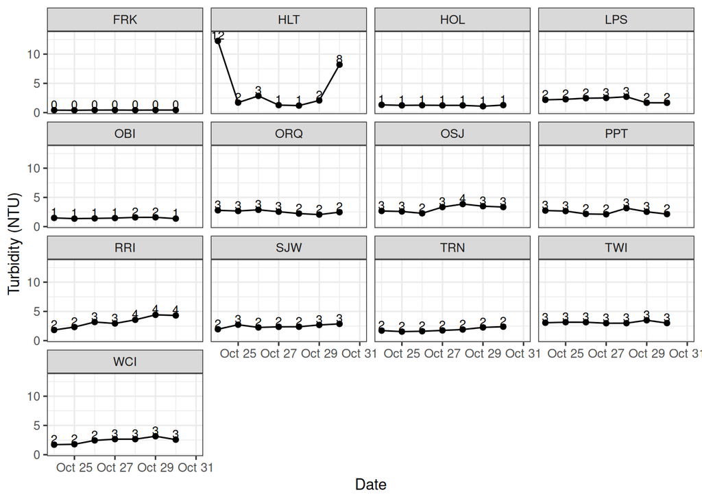

Here it is converted to secchi depth

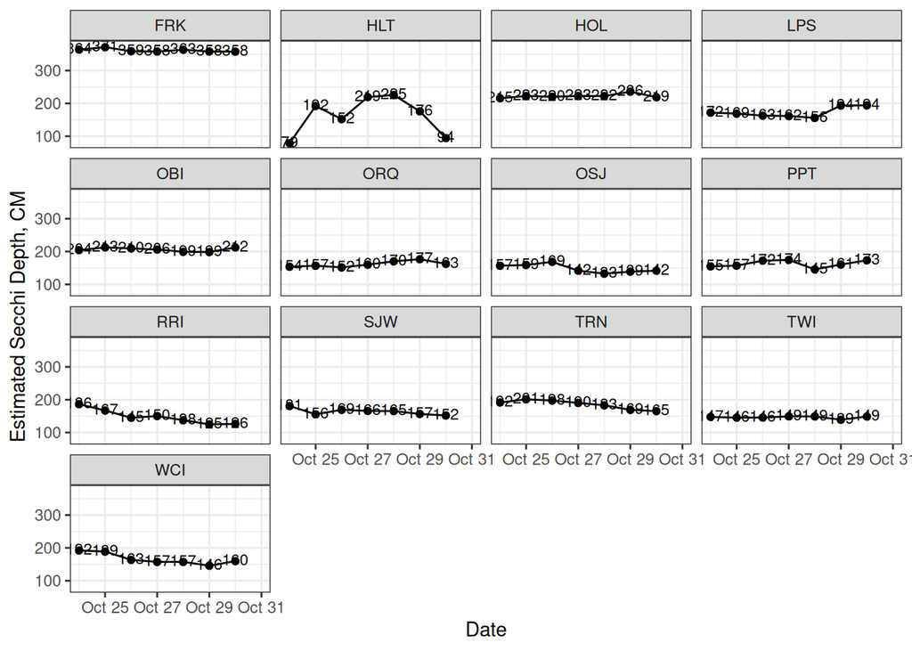

### A note on secchi conversions

Turbidity and secchi depth have a pretty good correlation when both are log-transformed. However, secchi depth is subject to some degree of variability with observer, weather, time of day, waves, and whether the observer has had their coffee. Turbidity, as measured by a sonde, is also subject to some variability depending on when the sonde was last calibrated.

We then log-transformed secchi depth and turbidity and conducted a linear regression.

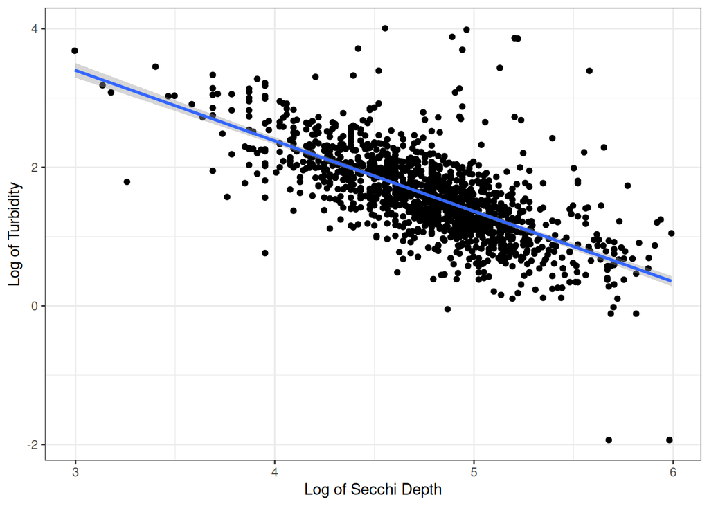

We used this regression to estimate the secchi depth given the turbidity from the continuous sondes.

Here’s the formula:

Secchi = exp(-0.45*log(Turbidity) +5.5)

Here is the model output:

```r
summary(convert3)
```

```
##
## Call:
## lm(formula = log(Secchi) ~ log(TurbiditySonde), data = filter(WQx2a,
##     ContStation != "OBI", ContStation != "FRK"))
##
## Residuals:
##      Min       1Q   Median       3Q      Max
## -1.43073 -0.18037 -0.00429  0.16137  1.61749
##
## Coefficients:
##                     Estimate Std. Error t value Pr(>|t|)
## (Intercept)          5.50163    0.02244  245.21   <2e-16 ***
## log(TurbiditySonde) -0.45390    0.01315  -34.52   <2e-16 ***
## ---
## Signif. codes:  0 '***' 0.001 '**' 0.01 '*' 0.05 '.' 0.1 ' ' 1
##
## Residual standard error: 0.3065 on 1392 degrees of freedom
## Multiple R-squared:  0.4612, Adjusted R-squared:  0.4608
## F-statistic:  1191 on 1 and 1392 DF,  p-value: < 2.2e-16
```

When we use this formula to predict secchi depth, we see that it fits reasonably well (r2 of 0.46) for secchi depths of between 50 and 200, but does less well in clear water and very turbid water due to the log-log relationship between turbidity and secchi. It also does not predict secchi depth in Franks Tract or near OBI very well.

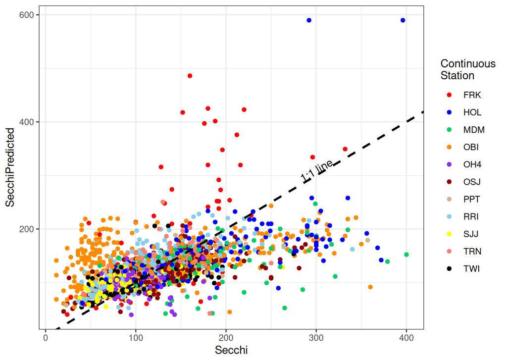

For all the code behind this analysis, please see:

https://github.com/EMRR-DISE/SMTWaterQuality